# Final Project V4

### In this tutorial, we will test various Recurrent Neural Networks to predict monthly sunspots.

Data can be found using the following link:: https://machinelearningmastery.com/time-series-datasets-for-machine-learning/

Recurrent neural networks are used for sequential data like time series, speech, text, and financial. RNN's have become increasingly popular in recent years and have enormous predicting power. An RNN differs from a feed-forward neural network because information cycles through a loop. In other words, an RNN remembers information from the past.

Below is an example of the difference between a feed forward neural network and an RNN.

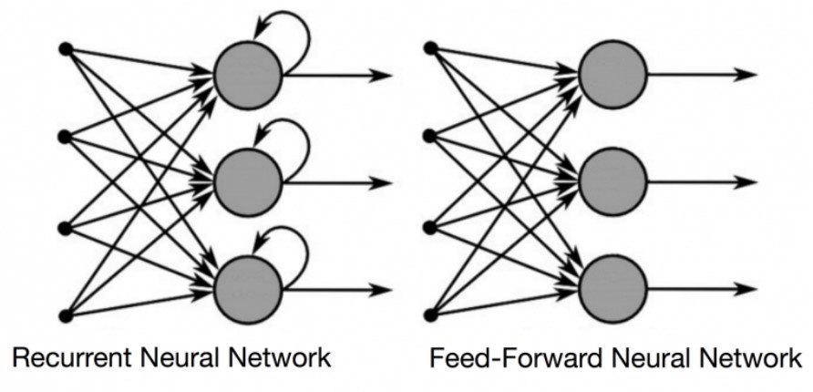

### Import packages

```python
import pandas as pd
import matplotlib.pyplot as plt
import pandas as pd
import numpy as np
from keras.models import Sequential
from keras.layers import Dense, SimpleRNN
from sklearn.metrics import mean_squared_error
import math
import matplotlib.pyplot as plt

from sklearn.preprocessing import MinMaxScaler
import warnings
warnings.filterwarnings('ignore')
```

Read in data and look at the first 5 rows. The data contains monthly number of sunspots. Sunspots are temporary phenomena on the Sun's surface that appear as spots darker than the surrounding areas. There are 2820 months in the dataset but for this purpose we will only analyze 1/4 of the data.

### Read in data

```python
df = pd.read_csv("https://raw.githubusercontent.com/jbrownlee/Datasets/master/monthly-sunspots.csv")
# look at first 5 rows
df.head()
```

|  | Month | Sunspots |
| --- | --- | --- |
| 0 | 1749-01 | 58.0 |
| 1 | 1749-02 | 62.6 |
| 2 | 1749-03 | 70.0 |
| 3 | 1749-04 | 55.7 |
| 4 | 1749-05 | 85.0 |

### Exploratory Data Analysis

```python
df.describe()
```

|  | Sunspots |
| --- | --- |
| count | 2820.000000 |
| mean | 51.265957 |
| std | 43.448971 |
| min | 0.000000 |
| 25% | 15.700000 |
| 50% | 42.000000 |
| 75% | 74.925000 |
| max | 253.800000 |

Using matplotlib to visualize monthly sunspots over time. From the plot, we can see the data contains seasonality with large differences between seasons. A time series model will perform well if it captures the trend and seasonality of the data and provides an accurate forecast.

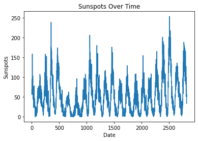

```python
# create plot
plt.plot(df["Sunspots"])

# Labelling
plt.xlabel("Date")
plt.ylabel("Sunspots")
plt.title("Sunspots Over Time")

# Display plot
plt.show()
```

### Defining functions

Create a function to build a recurrent neural network. Specifying the model as Sequential allows us to create our model layer by layer. We add a simple Recurrent Neural Network with specified parameters for the number of hidden units, dense units, input shape, and activation function. Then we add a dense layer, which means each neuron in the dense layer receives input from all neurons of its previous layer. The loss function we are looking to minimize is mean sqaured error.

```python
def create_RNN(hidden_units, dense_units, input_shape, activation):
    model = Sequential()
    model.add(SimpleRNN(hidden_units, input_shape=input_shape,
                        activation=activation[0]))
    model.add(Dense(units=dense_units, activation=activation[1]))
    model.compile(loss='mean_squared_error', optimizer='adam')
    return model
```

The function below reads in data from a csv file which can be found using the link: https://raw.githubusercontent.com/jbrownlee/Datasets/master/monthly-sunspots.csv. The data is scaled using min-max transformation. Min-Max scaling transforms every value between 0 and 1 by using the formula (x - min(x)) / (max(x) - min(x)). Then the data is split into training and test. The default split percent is 0.7, which means that 70% of data will be used for training and 30% for test. The split percent can be changed depending on the data or for testing purposes.

```python
def get_train_test(csv, split_percent=0.7):
    df = pd.read_csv(csv, usecols=[1], engine='python')
    df = df.tail(int(len(df) * .25))
    data = np.array(df.values.astype('float32'))
    # Scale data using min-max transformation
    scaler = MinMaxScaler(feature_range=(0, 1))
    data = scaler.fit_transform(data).flatten()
    n = len(data)
    # Point for splitting data into train and test
    split = int(n*split_percent)
    train_data = data[range(split)]
    test_data = data[split:]
    return train_data, test_data, data

csv = "https://raw.githubusercontent.com/jbrownlee/Datasets/master/monthly-sunspots.csv"
train_data, test_data, data = get_train_test(csv)
```

Returns independent and explanatory variables X and Y.

```python
def get_XY(dat, time_steps):
    # Indices of target array
    Y_ind = np.arange(time_steps, len(dat), time_steps)
    Y = dat[Y_ind]
    # Prepare X
    rows_x = len(Y)
    X = dat[range(time_steps*rows_x)]
    X = np.reshape(X, (rows_x, time_steps, 1))
    return X, Y
```

Creating a function to return both train and test rmse. The best performing model will have the lowest test rmse.

```python
test_rmse_values = []
def print_error(trainY, testY, train_predict, test_predict):
    # Error of predictions
    train_rmse = math.sqrt(mean_squared_error(trainY, train_predict))
    test_rmse = math.sqrt(mean_squared_error(testY, test_predict))
    # Print RMSE
    print('Train RMSE: %.3f RMSE' % (train_rmse))
    print('Test RMSE: %.3f RMSE' % (test_rmse))
    test_rmse_values.append(test_rmse)
    return test_rmse
```

Building a function to plot the model predictions vs the actual values. Adding labels and titles to the plot.

```python
def plot_result(trainY, testY, train_predict, test_predict):
    actual = np.append(trainY, testY)
    predictions = np.append(train_predict, test_predict)
    rows = len(actual)
    plt.figure(figsize=(15, 6), dpi=80)
    plt.plot(range(rows), actual)
    plt.plot(range(rows), predictions)
    plt.axvline(x=len(trainY), color='r')
    plt.legend(['Actual', 'Predictions'])
    plt.xlabel('Observation number after given time steps')
    plt.ylabel('MA scaled')
    plt.title('Actual and Predicted Values. The Red Line Separates The Training And Test Examples')
```

Combine functions to create one function that will create a recurrent neural network, split data, fit, predict, analyze and plot. Different activation functions can be specified for the first and second hidden layers, both with a default activation function of linear. Next, the number of time steps to be used in the model can be changed. Epochs can also be changed from a default value of 10. An epoch means training the neural network with all the training data for one cycle. In an epoch, we use all of the data exactly once.

```python
def run_rnn_model(activation = "linear", activation2 = "linear", num_timesteps = 1, optimizer = "adam",epochs = 10):
    #demo_model = create_RNN(2, 1, (3,1), activation=['linear', 'linear'])
    csv = "https://raw.githubusercontent.com/jbrownlee/Datasets/master/monthly-sunspots.csv"
    train_data, test_data, data = get_train_test(csv)
    time_steps = num_timesteps
    trainX, trainY = get_XY(train_data, time_steps)
    testX, testY = get_XY(test_data, time_steps)
    model = create_RNN(hidden_units=3, dense_units=1, input_shape=(time_steps,1),
                   activation=[activation, activation2])
    model.fit(trainX, trainY, epochs=epochs, batch_size=1, verbose=2)
    # make predictions
    train_predict = model.predict(trainX)
    test_predict = model.predict(testX)
    # Mean square error
    print_error(trainY, testY, train_predict, test_predict)
    print("first hidden layer activation = " + activation + ", second layer activation = " + activation2 + ", time steps = " + str(time_steps))
    plot_result(trainY, testY, train_predict, test_predict)
```

### Optimize the recurrent neural network

Testing different activation functions on each hidden layer as well as different time step values using nested for loops. The activation functions tested are linear, relu, and tanh. The time step values tested are 1, 2, and 3. We also test epoch values of 15 and 20. Each time a model is created lists get populated to store what the parameter values as well as the associated test rmse.

```python
%%capture
import tensorflow as tf
activation_functions = ["linear", "relu", "tanh"]
time_steps = [1, 2, 3]
epochs = [15, 20]


# create empty lists to hold parameter values
activation_function1_values = []
activation_function2_values = []
optimizer_values = []
time_steps_values = []
epoch_values = []

for activation_function in activation_functions:
    for activation_function2 in activation_functions:
        for time_step in time_steps:
            for epoch in epochs:
                activation_function1_values.append(activation_function)
                activation_function2_values.append(activation_function2)
                time_steps_values.append(time_step)
                epoch_values.append(epoch)
                run_rnn_model(activation_function, activation_function2, time_step, epochs = epoch)
```

### Look at model results

Create dataframe to see the model rmse of different parameter values.

```python
results = pd.concat([pd.DataFrame(activation_function1_values) ,
                   pd.DataFrame(activation_function2_values),
                   pd.DataFrame(epoch_values),
                   pd.DataFrame(time_steps_values),
                   pd.DataFrame(test_rmse_values)], axis=1)
results.columns = ['activation_function_1','activation_function_2',"epochs", "time_steps", "test_rmse"]
results
```

|  | activation_function_1 | activation_function_2 | epochs | time_steps | test_rmse |
| --- | --- | --- | --- | --- | --- |
| 0 | linear | linear | 15 | 1 | 0.076714 |
| 1 | linear | linear | 20 | 1 | 0.077129 |
| 2 | linear | linear | 15 | 2 | 0.134474 |
| 3 | linear | linear | 20 | 2 | 0.083794 |
| 4 | linear | linear | 15 | 3 | 0.111236 |
| 5 | linear | linear | 20 | 3 | 0.091696 |
| 6 | linear | relu | 15 | 1 | 0.078198 |
| 7 | linear | relu | 20 | 1 | 0.076224 |
| 8 | linear | relu | 15 | 2 | 0.083877 |
| 9 | linear | relu | 20 | 2 | 0.084651 |
| 10 | linear | relu | 15 | 3 | 0.111133 |
| 11 | linear | relu | 20 | 3 | 0.367775 |
| 12 | linear | tanh | 15 | 1 | 0.076113 |
| 13 | linear | tanh | 20 | 1 | 0.076736 |
| 14 | linear | tanh | 15 | 2 | 0.080022 |
| 15 | linear | tanh | 20 | 2 | 0.083001 |
| 16 | linear | tanh | 15 | 3 | 0.072655 |
| 17 | linear | tanh | 20 | 3 | 0.078746 |
| 18 | relu | linear | 15 | 1 | 0.199720 |
| 19 | relu | linear | 20 | 1 | 0.076662 |
| 20 | relu | linear | 15 | 2 | 0.101761 |
| 21 | relu | linear | 20 | 2 | 0.195888 |
| 22 | relu | linear | 15 | 3 | 0.194174 |
| 23 | relu | linear | 20 | 3 | 0.072205 |
| 24 | relu | relu | 15 | 1 | 0.370572 |
| 25 | relu | relu | 20 | 1 | 0.370572 |
| 26 | relu | relu | 15 | 2 | 0.084281 |
| 27 | relu | relu | 20 | 2 | 0.370197 |
| 28 | relu | relu | 15 | 3 | 0.367775 |
| 29 | relu | relu | 20 | 3 | 0.086975 |
| 30 | relu | tanh | 15 | 1 | 0.076948 |
| 31 | relu | tanh | 20 | 1 | 0.195005 |
| 32 | relu | tanh | 15 | 2 | 0.079953 |
| 33 | relu | tanh | 20 | 2 | 0.196134 |
| 34 | relu | tanh | 15 | 3 | 0.071710 |
| 35 | relu | tanh | 20 | 3 | 0.078322 |
| 36 | tanh | linear | 15 | 1 | 0.076250 |
| 37 | tanh | linear | 20 | 1 | 0.078058 |
| 38 | tanh | linear | 15 | 2 | 0.081108 |
| 39 | tanh | linear | 20 | 2 | 0.080664 |
| 40 | tanh | linear | 15 | 3 | 0.129354 |
| 41 | tanh | linear | 20 | 3 | 0.071659 |
| 42 | tanh | relu | 15 | 1 | 0.075760 |
| 43 | tanh | relu | 20 | 1 | 0.370572 |
| 44 | tanh | relu | 15 | 2 | 0.087651 |
| 45 | tanh | relu | 20 | 2 | 0.080495 |
| 46 | tanh | relu | 15 | 3 | 0.072927 |
| 47 | tanh | relu | 20 | 3 | 0.367775 |
| 48 | tanh | tanh | 15 | 1 | 0.078143 |
| 49 | tanh | tanh | 20 | 1 | 0.076321 |
| 50 | tanh | tanh | 15 | 2 | 0.081454 |
| 51 | tanh | tanh | 20 | 2 | 0.088722 |
| 52 | tanh | tanh | 15 | 3 | 0.073362 |
| 53 | tanh | tanh | 20 | 3 | 0.086634 |

```python
results = results.dropna()
results.sort_values("test_rmse").head(10)
```

|  | activation_function_1 | activation_function_2 | epochs | time_steps | test_rmse |
| --- | --- | --- | --- | --- | --- |
| 41 | tanh | linear | 20 | 3 | 0.071659 |
| 34 | relu | tanh | 15 | 3 | 0.071710 |
| 23 | relu | linear | 20 | 3 | 0.072205 |
| 16 | linear | tanh | 15 | 3 | 0.072655 |
| 46 | tanh | relu | 15 | 3 | 0.072927 |
| 52 | tanh | tanh | 15 | 3 | 0.073362 |
| 42 | tanh | relu | 15 | 1 | 0.075760 |
| 12 | linear | tanh | 15 | 1 | 0.076113 |
| 7 | linear | relu | 20 | 1 | 0.076224 |
| 36 | tanh | linear | 15 | 1 | 0.076250 |

### Final Model

```
492/492 - 1s - loss: 0.0208 - 899ms/epoch - 2ms/step
492/492 - 0s - loss: 0.0071 - 408ms/epoch - 829us/step
492/492 - 1s - loss: 0.0055 - 504ms/epoch - 1ms/step
492/492 - 1s - loss: 0.0054 - 501ms/epoch - 1ms/step
492/492 - 0s - loss: 0.0054 - 448ms/epoch - 912us/step
492/492 - 0s - loss: 0.0054 - 446ms/epoch - 906us/step
492/492 - 1s - loss: 0.0055 - 530ms/epoch - 1ms/step
492/492 - 0s - loss: 0.0053 - 464ms/epoch - 943us/step
492/492 - 0s - loss: 0.0055 - 423ms/epoch - 859us/step
492/492 - 0s - loss: 0.0054 - 448ms/epoch - 911us/step
492/492 - 0s - loss: 0.0054 - 423ms/epoch - 860us/step
492/492 - 0s - loss: 0.0054 - 455ms/epoch - 925us/step
492/492 - 0s - loss: 0.0055 - 444ms/epoch - 902us/step
492/492 - 0s - loss: 0.0054 - 459ms/epoch - 933us/step
492/492 - 0s - loss: 0.0054 - 432ms/epoch - 878us/step
Train RMSE: 0.073 RMSE
Test RMSE: 0.078 RMSE
first hidden layer activation = tanh, second layer activation = relu, time steps = 1
```

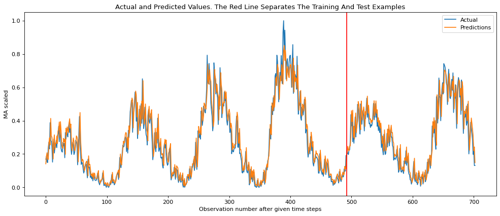

```python
run_rnn_model("tanh", "relu",epochs = 15, num_timesteps = 1)
```

### Summary

To improve the model, we could test different optimizers. Changing optimizers could allow the model to fit the small discrepencies in the data better. We could also try adding an LSTM layer to the neural network.